# Presentation2-Copy1

AR: Autoregression. A model that uses the dependent relationship between an observation and some number of lagged observations. I: Integrated. The use of differencing of raw observations (e.g. subtracting an observation from an observation at the previous time step) in order to make the time series stationary. MA: Moving Average. A model that uses the dependency between an observation and a residual error from a moving average model applied to lagged observations

ARIMA(1,1,0) = differenced first-order autoregressive model: If the errors of a random walk model are autocorrelated, perhaps the problem can be fixed by adding one lag of the dependent variable to the prediction equation--i.e., by regressing the first difference of Y on itself lagged by one period. This would yield the following prediction equation:

Ŷt - Yt-1 = μ + ϕ1(Yt-1 - Yt-2)

which can be rearranged to

Ŷt = μ + Yt-1 + ϕ1 (Yt-1 - Yt-2)

This is a first-order autoregressive model with one order of nonseasonal differencing and a constant term--i.e., an ARIMA(1,1,0) model.

```python
import pandas as pd
import os
import matplotlib.cm as cm
from matplotlib.offsetbox import AnchoredText as at
import numpy as np
from pandas import datetime
from matplotlib import pyplot
from pandas.tools.plotting import autocorrelation_plot
from statsmodels.tsa.arima_model import ARIMA
from pandas import DataFrame
from statsmodels.tsa.arima_model import ARIMA
from sklearn.metrics import mean_squared_error
```

```python
All = pd.read_csv("SalesALLNew_May.csv",encoding = "ISO-8859-1")
All['LINETOTAL'].sum()
```

```
47647452.58249
```

```python
All['LINETOTAL'].sum()
All['ZIPCODE'] = All['ZIPCODE'].str[:5]
#All['SHIP_TO_ZIP'].value_counts()
#All['CUST_TYPE_ID'] = pd.to_int(All['CUST_TYPE_ID'])
All['CUST_TYPE_ID'] = All['CUST_TYPE_ID'].fillna(0)
All['CUST_TYPE_ID'] = All['CUST_TYPE_ID'].astype(int)
#All['LINETOTAL'] = np.log(All['LINETOTAL']) / 2
All.info()
All['CUST_TYPE_ID'].unique()
```

```
<class 'pandas.core.frame.DataFrame'>
RangeIndex: 96160 entries, 0 to 96159
Data columns (total 7 columns):
DATE_TAKEN       96160 non-null object
ORDERNO          96158 non-null float64
LINETOTAL        96148 non-null float64
COMPANY          96160 non-null object
SHIP_TO_STATE    91004 non-null object
ZIPCODE          91744 non-null object
CUST_TYPE_ID     96160 non-null int32
dtypes: float64(2), int32(1), object(4)
memory usage: 4.8+ MB
```

```
array([ 2,  0, 15,  7,  1,  6,  4, 12, 11,  5,  3, 13], dtype=int64)
```

```python
All['Year'] = pd.DatetimeIndex(All['DATE_TAKEN']).year
All['Month'] = pd.DatetimeIndex(All['DATE_TAKEN']).month.astype(str)
All['Month'] = All['Month'].str.zfill(2)
All['YearMonth'] = All["Year"].map(str) + '-' + All["Month"].map(str)
All['YearMonth2'] = All["Year"].map(str) + All["Month"].map(str)
All.head()
```

|  | DATE_TAKEN | ORDERNO | LINETOTAL | COMPANY | SHIP_TO_STATE | ZIPCODE | CUST_TYPE_ID | Year | Month | YearMonth | YearMonth2 |
| --- | --- | --- | --- | --- | --- | --- | --- | --- | --- | --- | --- |
| 0 | 3/16/2016 | 370051.0 | 72.38 | HUTTER PERFORMANCE CENTER | OH | 44024 | 2 | 2016 | 03 | 2016-03 | 201603 |
| 1 | 3/16/2016 | 370053.0 | 14.00 | LETHAL PERFORMANCE | TX | 78238 | 0 | 2016 | 03 | 2016-03 | 201603 |
| 2 | 3/16/2016 | 370053.0 | 94.00 | LETHAL PERFORMANCE | TX | 78238 | 0 | 2016 | 03 | 2016-03 | 201603 |
| 3 | 3/16/2016 | 370053.0 | 54.00 | LETHAL PERFORMANCE | TX | 78238 | 0 | 2016 | 03 | 2016-03 | 201603 |
| 4 | 3/16/2016 | 370054.0 | 14.00 | SUPERCHARGER CONNECTION-JPA CAPITAL | NJ | 07094 | 2 | 2016 | 03 | 2016-03 | 201603 |

```python
FinalAll = All[['ORDERNO','LINETOTAL','YearMonth','YearMonth2','SHIP_TO_STATE','ZIPCODE','CUST_TYPE_ID']].copy()
#FinalAll.rename(columns={'SHIP_TO_ZIP': 'ZipCode'}, inplace=True)
#FinalAll['TotalDollars'] = pd.DataFrame(All.groupby('SHIP_TO_STATE')['LINETOTAL'].sum())

FinalAll.head()
```

|  | ORDERNO | LINETOTAL | YearMonth | YearMonth2 | SHIP_TO_STATE | ZIPCODE | CUST_TYPE_ID |
| --- | --- | --- | --- | --- | --- | --- | --- |
| 0 | 370051.0 | 72.38 | 2016-03 | 201603 | OH | 44024 | 2 |
| 1 | 370053.0 | 14.00 | 2016-03 | 201603 | TX | 78238 | 0 |
| 2 | 370053.0 | 94.00 | 2016-03 | 201603 | TX | 78238 | 0 |
| 3 | 370053.0 | 54.00 | 2016-03 | 201603 | TX | 78238 | 0 |
| 4 | 370054.0 | 14.00 | 2016-03 | 201603 | NJ | 07094 | 2 |

```python
CUSTS = ['12','13','14','15']

FinalAll = FinalAll[~All.CUST_TYPE_ID.isin(CUSTS)]

#FinalAll['LINETOTAL'] = FinalAll['LINETOTAL']/3
```

```python
Series = FinalAll[['YearMonth','LINETOTAL']].copy()
#Series['YearMonth'] = Series['YearMonth'] + str('-01')
Series['YearMonth'] = Series['YearMonth'].apply(lambda x: pd.to_datetime(str(x), format='%Y%m%'))
Series.head()
```

|  | YearMonth | LINETOTAL |
| --- | --- | --- |
| 0 | 2016-03-01 | 72.38 |
| 1 | 2016-03-01 | 14.00 |
| 2 | 2016-03-01 | 94.00 |
| 3 | 2016-03-01 | 54.00 |
| 4 | 2016-03-01 | 14.00 |

```python
SeriesGroup = Series.groupby('YearMonth')['LINETOTAL'].sum()
SeriesGroup
```

```
YearMonth
2016-01-01    9.716254e+05
2016-02-01    1.334962e+06
2016-03-01    1.607099e+06
2016-04-01    1.347800e+06
2016-05-01    1.373291e+06
2016-06-01    1.282013e+06
2016-07-01    1.126199e+06
2016-08-01    1.509863e+06
2016-09-01    1.269873e+06
2016-10-01    1.257610e+06
2016-11-01    1.311460e+06
2016-12-01    1.142478e+06
2017-01-01    1.315341e+06
2017-02-01    1.422611e+06
2017-03-01    2.106156e+06
2017-04-01    1.706116e+06
2017-05-01    1.700003e+06
2017-06-01    1.607850e+06
2017-07-01    1.267640e+06
2017-08-01    1.565210e+06
2017-09-01    1.224443e+06
2017-10-01    1.270908e+06
2017-11-01    1.344679e+06
2017-12-01    1.112497e+06
2018-01-01    1.897698e+06
2018-02-01    1.544334e+06
2018-03-01    2.075964e+06
2018-04-01    1.855458e+06
2018-05-01    1.653249e+06
Name: LINETOTAL, dtype: float64
```

[output not shown]

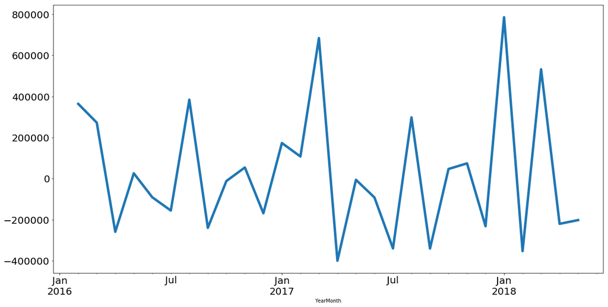

```python
SeriesGroup.diff().plot(figsize=(20,10), linewidth=5, fontsize=20)
plt.xlabel('Year', fontsize=20)
plt.show()
```

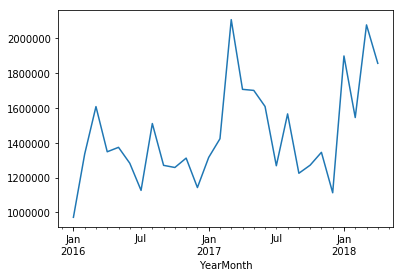

```python
SeriesGroup[:-1].plot()
pyplot.show()
```

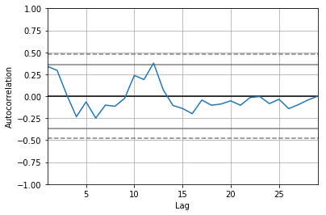

```python
autocorrelation_plot(SeriesGroup)
pyplot.show()
```

```python
# fit model
model = ARIMA(SeriesGroup, order=(1,1,0))
model_fit = model.fit(disp=0)
print(model_fit.summary())
```

```
                             ARIMA Model Results
==============================================================================
Dep. Variable:            D.LINETOTAL   No. Observations:                   28
Model:                 ARIMA(1, 1, 0)   Log Likelihood                -390.204
Method:                       css-mle   S.D. of innovations         271626.571
Date:                Thu, 14 Jun 2018   AIC                            786.407
Time:                        10:37:03   BIC                            790.404
Sample:                    02-01-2016   HQIC                           787.629
                         - 05-01-2018
=====================================================================================
                        coef    std err          z      P>|z|      [0.025      0.975]
-------------------------------------------------------------------------------------
const              2.158e+04    3.5e+04      0.616      0.543   -4.71e+04    9.03e+04
ar.L1.D.LINETOTAL    -0.4821      0.166     -2.908      0.007      -0.807      -0.157
                                    Roots
=============================================================================
                 Real           Imaginary           Modulus         Frequency
-----------------------------------------------------------------------------
AR.1           -2.0741           +0.0000j            2.0741            0.5000
-----------------------------------------------------------------------------
```

```
                             ARIMA Model Results
==============================================================================
Dep. Variable:            D.LINETOTAL   No. Observations:                   28
Model:                 ARIMA(1, 1, 0)   Log Likelihood                -390.204
Method:                       css-mle   S.D. of innovations         271626.571
Date:                Thu, 14 Jun 2018   AIC                            786.407
Time:                        10:37:07   BIC                            790.404
Sample:                    02-01-2016   HQIC                           787.629
                         - 05-01-2018
=====================================================================================
                        coef    std err          z      P>|z|      [0.025      0.975]
-------------------------------------------------------------------------------------
const              2.158e+04    3.5e+04      0.616      0.543   -4.71e+04    9.03e+04
ar.L1.D.LINETOTAL    -0.4821      0.166     -2.908      0.007      -0.807      -0.157
                                    Roots
=============================================================================
                 Real           Imaginary           Modulus         Frequency
-----------------------------------------------------------------------------
AR.1           -2.0741           +0.0000j            2.0741            0.5000
-----------------------------------------------------------------------------
```

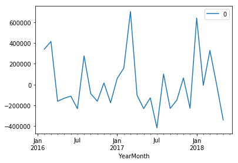

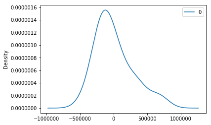

```
                   0
count      28.000000
mean     7953.763447
std    278304.929421
min   -416621.897929
25%   -163802.368436
50%    -94720.580937
75%    115827.691567
max    703284.120478
[1782723.43109709]
```

```python
# fit model
model = ARIMA(SeriesGroup, order=(1,1,0))
model_fit = model.fit(disp=0)
print(model_fit.summary())
# plot residual errors
residuals = DataFrame(model_fit.resid)
residuals.plot()
pyplot.show()
residuals.plot(kind='kde')
pyplot.show()
print(residuals.describe())
output = model_fit.forecast()[0]
print(output)
```

```
predicted=1378424.029859, expected=1565210.185233
predicted=1514100.992780, expected=1224443.132550
predicted=1368204.026705, expected=1270907.521697
predicted=1273937.125916, expected=1344678.888725
predicted=1341951.744699, expected=1112496.503615
predicted=1204179.988694, expected=1897698.328565
predicted=1608690.185668, expected=1544334.014815
predicted=1742082.545077, expected=2075964.279672
predicted=1846594.066348, expected=1855457.762432
predicted=2018638.563182, expected=1653248.658924
Test MSE: 91608622278.670
```

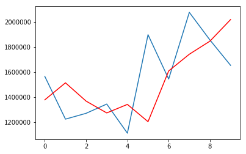

```python
X = SeriesGroup.values
size = int(len(X) * 0.66)
train, test = X[0:size], X[size:len(X)]
history = [x for x in train]
predictions = list()
for t in range(len(test)):
    model = ARIMA(history, order=(1,1,0))
    model_fit = model.fit(disp=0)
    output = model_fit.forecast()
    yhat = output[0]
    predictions.append(yhat)
    obs = test[t]
    history.append(obs)
    print('predicted=%f, expected=%f' % (yhat, obs))
error = mean_squared_error(test, predictions)
print('Test MSE: %.3f' % error)
# plot
pyplot.plot(test)
pyplot.plot(predictions, color='red')
pyplot.show()
```

```
                   0
count      28.000000
mean     7953.763447
std    278304.929421
min   -416621.897929
25%   -163802.368436
50%    -94720.580937
75%    115827.691567
max    703284.120478
[19391.96700766]
Forecast: 1627242.184249
```

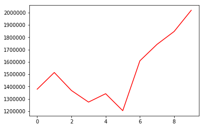

```python
# create a differenced series
def difference(SeriesGroup, interval=1):
	diff = list()
	for i in range(interval, len(SeriesGroup)):
		value = SeriesGroup[i] - SeriesGroup[i - interval]
		diff.append(value)
	return np.array(diff)

# invert differenced value
def inverse_difference(history, yhat, interval=1):
	return yhat + history[-interval]

# load dataset
#series = Series.from_csv('dataset.csv', header=None)
# seasonal difference
X = SeriesGroup.values
months_in_year = 12
differenced = difference(X, months_in_year)
# fit model
model = ARIMA(differenced, order=(1,1,0))
model_fit = model.fit(disp=0)
# one-step out-of sample forecast
forecast = model_fit.forecast(steps=1)[0]
# invert the differenced forecast to something usable
forecast = inverse_difference(X, forecast, months_in_year)
print(residuals.describe())
output = model_fit.forecast()[0]
print(output)
print('Forecast: %f' % forecast)
#pyplot.plot(difference)
pyplot.plot(predictions, color='red')
#pyplot.plot(residuals)
pyplot.show()
```

```python
SeriesGroup[:-1]
```

```
YearMonth
2016-01-01    9.716254e+05
2016-02-01    1.334962e+06
2016-03-01    1.607099e+06
2016-04-01    1.347800e+06
2016-05-01    1.373291e+06
2016-06-01    1.282013e+06
2016-07-01    1.126199e+06
2016-08-01    1.509863e+06
2016-09-01    1.269873e+06
2016-10-01    1.257610e+06
2016-11-01    1.311460e+06
2016-12-01    1.142478e+06
2017-01-01    1.315341e+06
2017-02-01    1.422611e+06
2017-03-01    2.106156e+06
2017-04-01    1.706116e+06
2017-05-01    1.700003e+06
2017-06-01    1.607850e+06
2017-07-01    1.267640e+06
2017-08-01    1.565210e+06
2017-09-01    1.224443e+06
2017-10-01    1.270908e+06
2017-11-01    1.344679e+06
2017-12-01    1.112497e+06
2018-01-01    1.897698e+06
2018-02-01    1.544334e+06
2018-03-01    2.075964e+06
2018-04-01    1.855458e+06
Name: LINETOTAL, dtype: float64
```

```python
from pandas import Series
from statsmodels.tsa.arima_model import ARIMA
import numpy
history = []
Fore=[]
Fore2=[]
# load dataset
SeriesGroup
# seasonal difference
#X = SeriesGroup.values
#X = SeriesGroup[:-1].values
months_in_year = 12
differenced = difference(X, months_in_year)
# fit model
model = ARIMA(differenced, order=(1,1,0))
model_fit = model.fit(disp=0)
# multi-step out-of-sample forecast
forecast = model_fit.forecast(steps=12)[0]
# invert the differenced forecast to something usable
history = [x for x in X]
month = 1
#print(forecast)
#print(forecast[4:])

for yhat in forecast:
    inverted = inverse_difference(history, yhat, months_in_year)
    Fore.append('%f' %inverted)
    Fore2.append(forecast[4:])
    history.append(inverted)
    month += 1
Fore1 = pd.DataFrame(Fore)
#Fore1.to_csv('Pres2',encoding='utf-8')
Fore1 = Fore1.append(Fore2, ignore_index=True)
Fore1
```

|  | 0 | 1 | 2 | 3 | 4 | 5 | 6 | 7 |
| --- | --- | --- | --- | --- | --- | --- | --- | --- |
| 0 | 1627242.184249 | NaN | NaN | NaN | NaN | NaN | NaN | NaN |
| 1 | 1229037.092966 | NaN | NaN | NaN | NaN | NaN | NaN | NaN |
| 2 | 1527378.893960 | NaN | NaN | NaN | NaN | NaN | NaN | NaN |
| 3 | 1159564.359983 | NaN | NaN | NaN | NaN | NaN | NaN | NaN |
| 4 | 1192150.334104 | NaN | NaN | NaN | NaN | NaN | NaN | NaN |
| 5 | 1245809.266048 | NaN | NaN | NaN | NaN | NaN | NaN | NaN |
| 6 | 996465.528740 | NaN | NaN | NaN | NaN | NaN | NaN | NaN |
| 7 | 1763109.007239 | NaN | NaN | NaN | NaN | NaN | NaN | NaN |
| 8 | 1391847.661212 | NaN | NaN | NaN | NaN | NaN | NaN | NaN |
| 9 | 1905267.838505 | NaN | NaN | NaN | NaN | NaN | NaN | NaN |
| 10 | 1666699.428941 | NaN | NaN | NaN | NaN | NaN | NaN | NaN |
| 11 | 1446358.279912 | NaN | NaN | NaN | NaN | NaN | NaN | NaN |
| 12 | -78757.2 | -98869.622677 | -116030.974875 | -134589.321326 | -152486.353603 | -170696.441167 | -188758.333491 | -206890.379012 |
| 13 | -78757.2 | -98869.622677 | -116030.974875 | -134589.321326 | -152486.353603 | -170696.441167 | -188758.333491 | -206890.379012 |
| 14 | -78757.2 | -98869.622677 | -116030.974875 | -134589.321326 | -152486.353603 | -170696.441167 | -188758.333491 | -206890.379012 |
| 15 | -78757.2 | -98869.622677 | -116030.974875 | -134589.321326 | -152486.353603 | -170696.441167 | -188758.333491 | -206890.379012 |
| 16 | -78757.2 | -98869.622677 | -116030.974875 | -134589.321326 | -152486.353603 | -170696.441167 | -188758.333491 | -206890.379012 |
| 17 | -78757.2 | -98869.622677 | -116030.974875 | -134589.321326 | -152486.353603 | -170696.441167 | -188758.333491 | -206890.379012 |
| 18 | -78757.2 | -98869.622677 | -116030.974875 | -134589.321326 | -152486.353603 | -170696.441167 | -188758.333491 | -206890.379012 |
| 19 | -78757.2 | -98869.622677 | -116030.974875 | -134589.321326 | -152486.353603 | -170696.441167 | -188758.333491 | -206890.379012 |
| 20 | -78757.2 | -98869.622677 | -116030.974875 | -134589.321326 | -152486.353603 | -170696.441167 | -188758.333491 | -206890.379012 |
| 21 | -78757.2 | -98869.622677 | -116030.974875 | -134589.321326 | -152486.353603 | -170696.441167 | -188758.333491 | -206890.379012 |
| 22 | -78757.2 | -98869.622677 | -116030.974875 | -134589.321326 | -152486.353603 | -170696.441167 | -188758.333491 | -206890.379012 |
| 23 | -78757.2 | -98869.622677 | -116030.974875 | -134589.321326 | -152486.353603 | -170696.441167 | -188758.333491 | -206890.379012 |

```python
# create a differenced series
split_point = len(SeriesGroup) - 12
dataset, validation = SeriesGroup[0:split_point], SeriesGroup[split_point:]
history = [x for x in dataset]
def difference(dataset, interval=1):
	diff = list()
	for i in range(interval, len(dataset)):
		value = dataset[i] - dataset[i - interval]
		diff.append(value)
	return numpy.array(diff)
```

```python
# invert differenced value
def inverse_difference(history, yhat, interval=1):
    return yhat + history[-interval]
```

```python
from pandas import Series
from statsmodels.tsa.arima_model import ARIMA
import numpy
from pandas import datetime


# load dataset
series = dataset
# seasonal difference
#X = SeriesGroup[:-1].values
X = SeriesGroup
months_in_year = 12
differenced = difference(X, months_in_year)
# fit model
model = ARIMA(differenced, order=(1,1,0))
model_fit = model.fit(disp=0)
# one-step out of sample forecast
start_index = len(differenced)
end_index = len(differenced)
forecast = model_fit.predict(start=start_index, end=end_index)
# invert the differenced forecast to something usable
forecast = inverse_difference(X, forecast, months_in_year)
print('Forecast: %f' % forecast)
forecast = model_fit.forecast(steps=12)[0]
history = [x for x in X]
month = 19
for yhat in forecast:
	inverted = inverse_difference(history, yhat, months_in_year)
	print('Month %d: %f' % (month, inverted))
	history.append(inverted)
	month += 1
```

```
Forecast: 1673996.454474
Month 19: 1627242.184249
Month 20: 1229037.092966
Month 21: 1527378.893960
Month 22: 1159564.359983
Month 23: 1192150.334104
Month 24: 1245809.266048
Month 25: 996465.528740
Month 26: 1763109.007239
Month 27: 1391847.661212
Month 28: 1905267.838505
Month 29: 1666699.428941
Month 30: 1446358.279912
```

```python
print(validation)
```

```
YearMonth
2017-06-01    1.607850e+06
2017-07-01    1.267640e+06
2017-08-01    1.565210e+06
2017-09-01    1.224443e+06
2017-10-01    1.270908e+06
2017-11-01    1.344679e+06
2017-12-01    1.112497e+06
2018-01-01    1.897698e+06
2018-02-01    1.544334e+06
2018-03-01    2.075964e+06
2018-04-01    1.855458e+06
2018-05-01    1.653249e+06
Name: LINETOTAL, dtype: float64
```